# PCA on Faces Dataset

In this assignment, we will use PCA for dimensionality reduction on the MIT Face Recognition Dataset (https://courses.media.mit.edu/2004fall/mas622j/04.projects/faces/). The following code collects images from the folder rawdata and stores them in a 128x128x(number of images) tensor - image_collection. Running this might take about 20 minutes. If it takes more for you, you can break the loop after 1000 images.

```python
import os
import skimage
import numpy as np
import matplotlib.pyplot as plt
from skimage import measure

directory = os.fsencode('rawdata/')
image_collection = np.zeros((128,128,1))
count=0
for file in os.listdir(directory):
    count= count+1
    filename = os.fsdecode(file)
    temp_image = np.fromfile('rawdata/'+filename, dtype='uint8', sep="")
    ratio = temp_image.shape[0]/16384
    if ratio>1:
        temp_image = np.reshape(temp_image, (128*int(np.sqrt(ratio)), 128*int(np.sqrt(ratio))))
        temp_image = measure.block_reduce(temp_image, (int(np.sqrt(ratio)),int(np.sqrt(ratio))), np.mean)
    image_collection = np.concatenate((image_collection,np.reshape(temp_image,(128,128,1))),axis=2)
    #if count==1000:
    #    break
image_collection = image_collection[:,:,1:]
```

# Problem 1

Recall that PCA requires centered data(zero mean). Center image_collection and display the mean image in gray scale using matplotlib

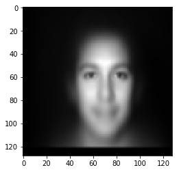

```python
#========Your code here ======
mean=np.zeros((128,128));
for i in range(image_collection.shape[0]):
    for j in range(image_collection.shape[1]):
        mean[i][j]=np.mean(image_collection[i,j,:])
#mean=np.mean(image_collection,2)

image_collection_centered=np.zeros(image_collection.shape);
for i in range(image_collection.shape[2]):
    image_collection_centered[:,:,i]=image_collection[:,:,i]-mean
plt.imshow(mean, cmap='gray')
#==============================
plt.show()
```

# Problem 2

Perform PCA on the images using sklearn. Plot the total percentage of variance explained versus number of components. Also plot the minimum percentage of variance explained versus number of components. Finally plot the singular values when number of components is 500. Justify the plots.

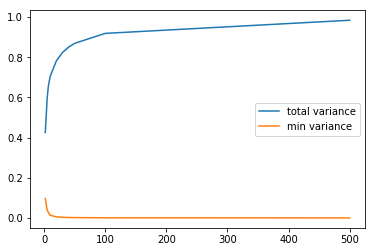

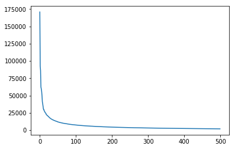

```python
num_comp = [2,5,7,10,20,30,40,50,100,500]
#========Your code here ======
from sklearn.decomposition import PCA
image_collection_centered_re=image_collection_centered.reshape((16384, image_collection_centered.shape[2])).T
total_variance_explained=[]
min_variance=[]
for i in num_comp:
    pca = PCA(n_components=i).fit(image_collection_centered_re)
    total_variance_explained.append(sum(pca.explained_variance_ratio_))
    min_variance.append(min(pca.explained_variance_ratio_))
    if i==500:
        singular_values=pca.singular_values_

#==============================
plt.figure(1)
plt.plot(num_comp,total_variance_explained,label='total variance')
plt.plot(num_comp, min_variance,label = 'min variance')
plt.legend()
plt.show()
plt.figure(2)
plt.plot(range(500),singular_values)
plt.show()
```

The total variance is small when the principal component is small. As the top principal component grows, the total variance increases. For the min variance is quite the opposite. The min variance is relatively big when the principal component is small and it decreases when the principal component is big. The singular values corresponding to the top principal components are larger ang it decreases whe nthe principal component is big. Since the singular values are the square root of eigenvalues of $X^{T}X$ and the principal components are eigenvectors of it, the singular value would be big when the principal component is small. The decease shows how many principal components are needed to capture the most of the dataset.

# Problem 3

Display the first 5 principal components as images in gray scale using matplotlib. Explain your observations.

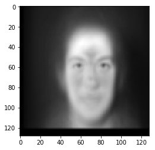

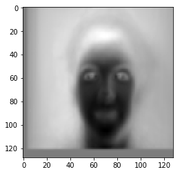

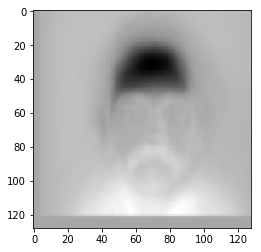

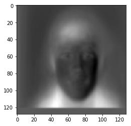

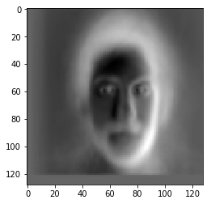

```python
#========Your code here ======
for i in range(5):
    comp=pca.components_[i,:].reshape((128,128))
    plt.figure()
    plt.imshow(comp, cmap='gray')

#==============================
```

They are all face image. That shows thatthe top five principal component has the information and can represent the data.

Project the data matrix on the first two principal components and plot a scatter plot of the dataset

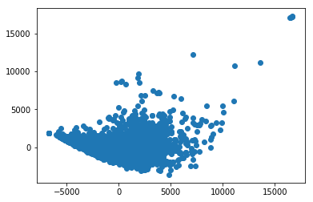

```python
#========Your code here ======
projection=pca.transform(image_collection_centered_re)

#==============================
plt.scatter(projection[:,0], projection[:,1])
plt.show()
```